# PP model comparisons

This is a comparison of variations of BIOv2 with BIOv1 and VGPM, using input collected from the panCanadian dataset. Input is from monthly composites, output is total daily primary production (mg C / m<sup>2</sup> / day), averaged over the month. BIOv2 uses CHL_POLY4, and the other models use CHL_OCX. Here, BIOv2 still uses the same PI parameters and biomass profile parameters as BIOv1 to allow a more direct comparison between the two models, however the parameters *B0* and *h* are scaled using POLY4 instead of OCx (scaling is necessary so that the surface value of the biomass profile is equal to the satellite value).

Note that with the exception of the MODIS cloud cover fraction used in BIO_v1, all of these models use data from VIIRS-SNPP.

First, the PI parameters alphaB and PmB, along with log10(chl) are mapped to show spatial patterns that influence models BIOv1 and BIOv2_VPI_NU. Second, BIOv1 and VGPM models are mapped, and variations of the new models:

1. *VPI_NU* - variable PI parameters (i.e. allowed to vary pixel-to-pixel) with nonuniform biomass profile (biomass profile parameters also vary by pixel)
2. *MPI_U* - median PI parameters of the whole region, and uniform biomass profile

The percent difference between the new model and BIOv1 and VGPM are mapped, with a table of Pearson’s correlation coefficients between percent difference and three variables: chla, latitude, bathymetry. Note that the x-axis range of the density plots is the mean +- 2stdev.

`% difference = (100 * (BIOv2 - y) / y)`  
y = BIOv1 or VGPM

## Results

### 201210

#### Input variables for BIOv1

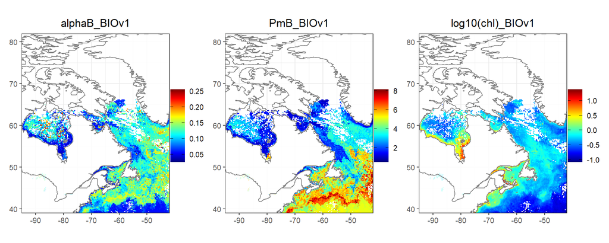

#### Monthly average daily PP: BIOv1 and VGPM

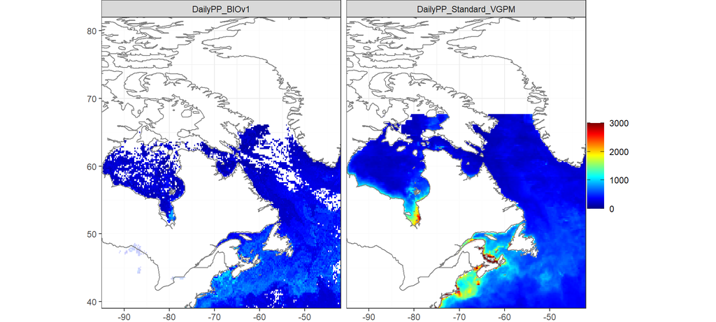

##### BIOv2 VPI_NU, and % difference from BIOv1 and VGPM

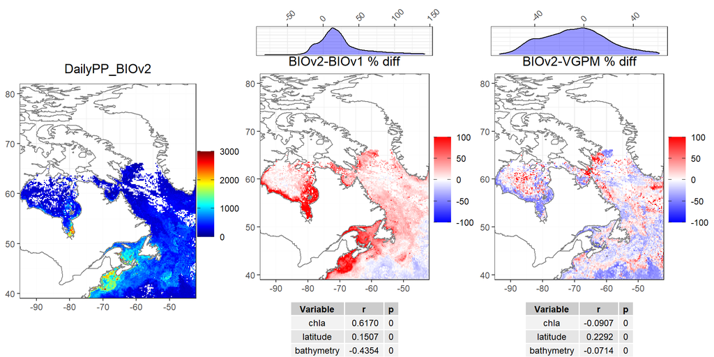

##### BIOv2 MPI_U, and % difference from BIOv1 and VGPM

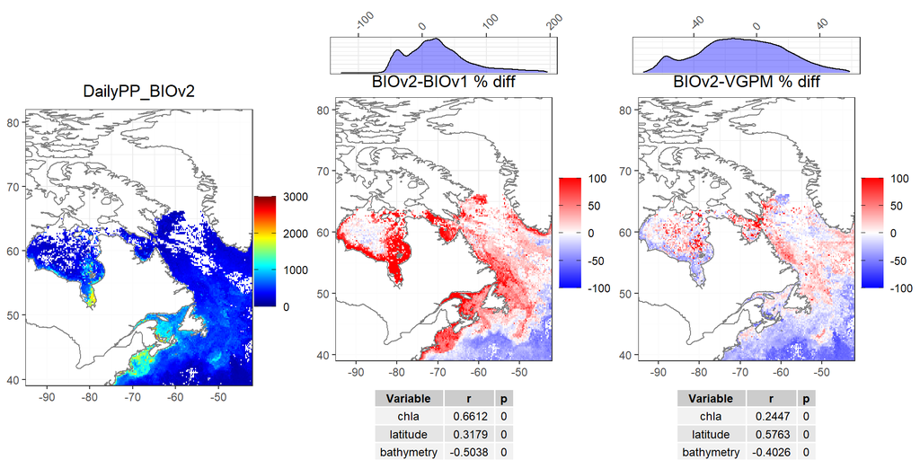

### 201501

#### Input variables for BIOv1

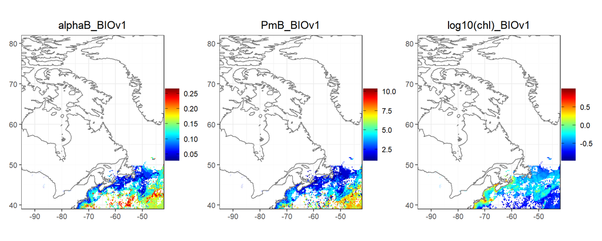

#### Monthly average daily PP: BIOv1 and VGPM

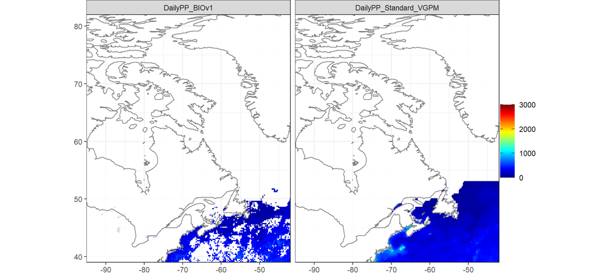

##### BIOv2 VPI_NU, and % difference from BIOv1 and VGPM

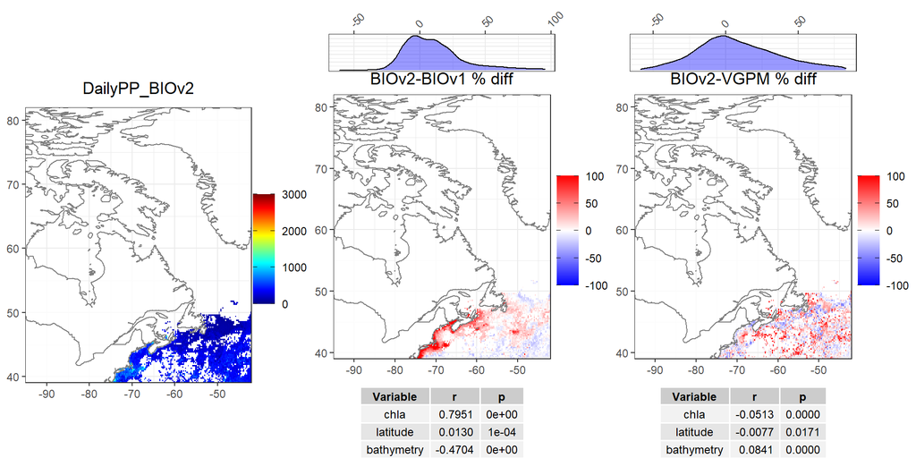

##### BIOv2 MPI_U, and % difference from BIOv1 and VGPM

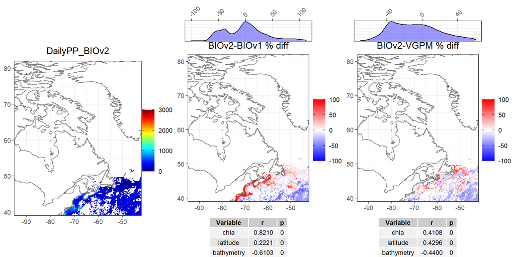

### 201704

#### Input variables for BIOv1

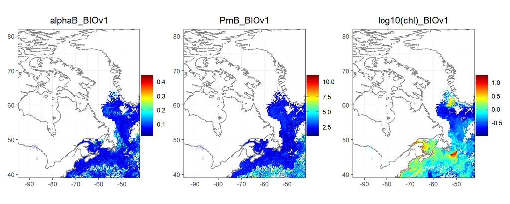

#### Monthly average daily PP: BIOv1 and VGPM

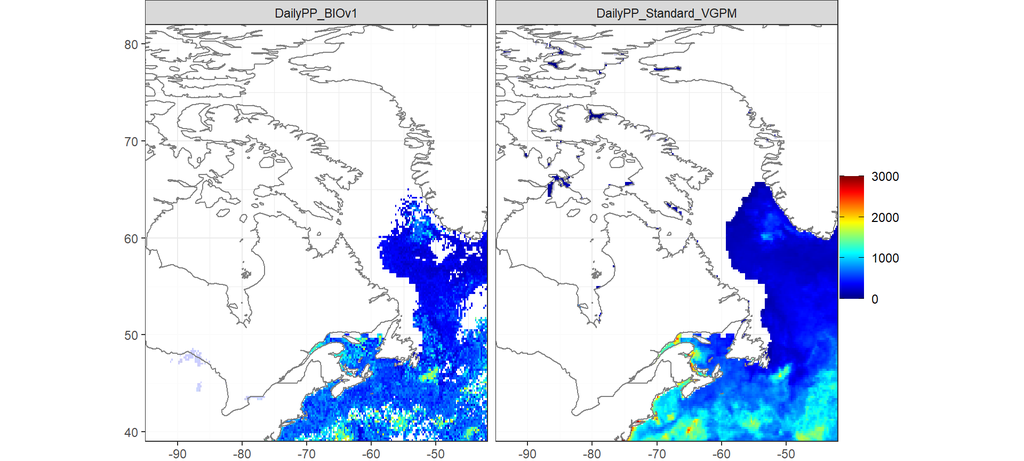

##### BIOv2 VPI_NU, and % difference from BIOv1 and VGPM

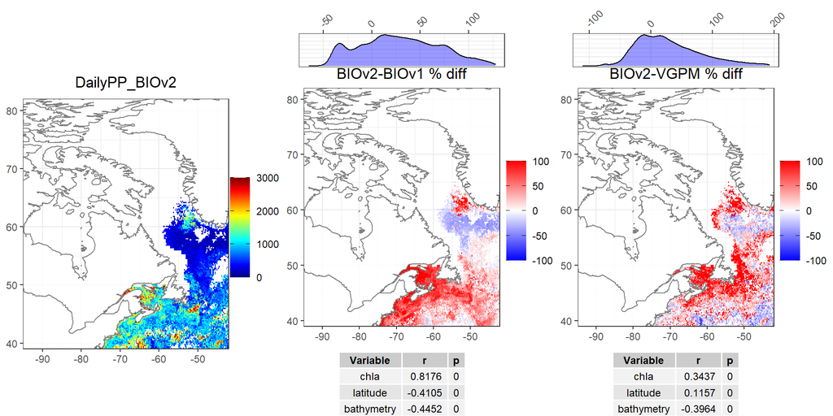

##### BIOv2 MPI_U, and % difference from BIOv1 and VGPM

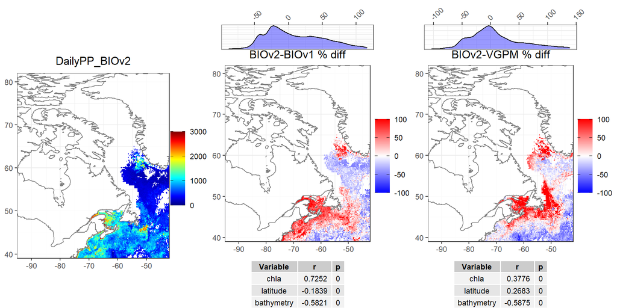

### 201807

#### Input variables for BIOv1

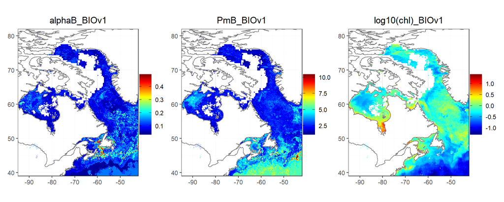

#### Monthly average daily PP: BIOv1 and VGPM

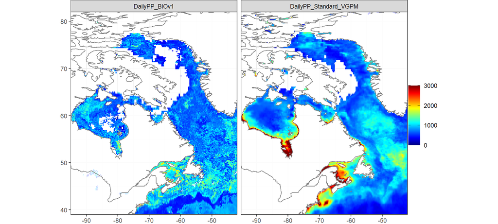

##### BIOv2 VPI_NU, and % difference from BIOv1 and VGPM

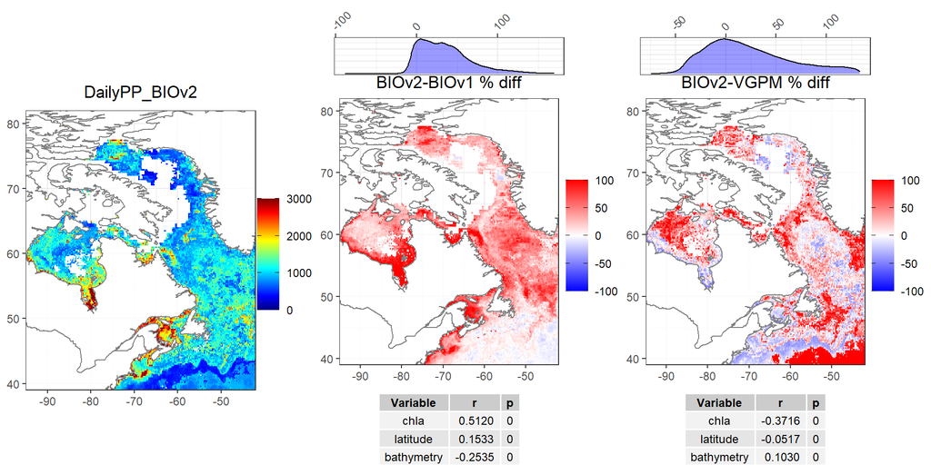

##### BIOv2 MPI_U, and % difference from BIOv1 and VGPM

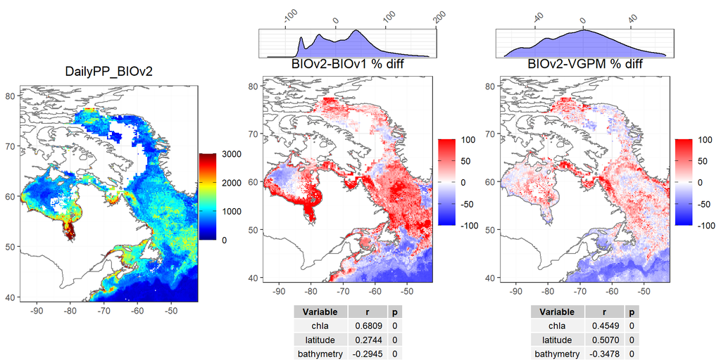